# LogisticRegression

estimating model with glm binomial mode

```r
logit1 <- glm(good ~ fico, data=loan,family = "binomial")
summary(logit1)
```

```
##
## Call:
## glm(formula = good ~ fico, family = "binomial", data = loan)
##
## Deviance Residuals:
##     Min       1Q   Median       3Q      Max
## -2.5172   0.4078   0.5306   0.6294   0.9622
##
## Coefficients:
##              Estimate Std. Error z value Pr(>|z|)
## (Intercept) -7.033068   0.296922  -23.69   <2e-16 ***
## fico         0.012358   0.000421   29.35   <2e-16 ***
## ---
## Signif. codes:  0 '***' 0.001 '**' 0.01 '*' 0.05 '.' 0.1 ' ' 1
##
## (Dispersion parameter for binomial family taken to be 1)
##
##     Null deviance: 35928  on 42534  degrees of freedom
## Residual deviance: 34985  on 42533  degrees of freedom
## AIC: 34989
##
## Number of Fisher Scoring iterations: 5
```

```r
exp(coef(logit1))
```

```
##  (Intercept)         fico
## 0.0008822209 1.0124345145
```

estimating probability

```r
test <- data.frame(fico=c(700,750))
test$pred <- predict(logit1,test, type="response")
test
```

```
##   fico      pred
## 1  700 0.8344391
## 2  750 0.9033761
```

multiple regression

```r
logit2 <- glm(good ~ fico + loan_amnt, data = loan, family = "binomial")
summary(logit2)
```

```
##
## Call:
## glm(formula = good ~ fico + loan_amnt, family = "binomial", data = loan)
##
## Deviance Residuals:
##     Min       1Q   Median       3Q      Max
## -2.6261   0.4011   0.5256   0.6261   0.9423
##
## Coefficients:
##               Estimate Std. Error z value Pr(>|z|)
## (Intercept) -7.367e+00  3.007e-01  -24.50   <2e-16 ***
## fico         1.319e-02  4.306e-04   30.62   <2e-16 ***
## loan_amnt   -2.229e-05  1.815e-06  -12.28   <2e-16 ***
## ---
## Signif. codes:  0 '***' 0.001 '**' 0.01 '*' 0.05 '.' 0.1 ' ' 1
##
## (Dispersion parameter for binomial family taken to be 1)
##
##     Null deviance: 35928  on 42534  degrees of freedom
## Residual deviance: 34838  on 42532  degrees of freedom
## AIC: 34844
##
## Number of Fisher Scoring iterations: 5
```

```r
exp(coef(logit2))
```

```
##  (Intercept)         fico    loan_amnt
## 0.0006316636 1.0132732517 0.9999777084
```

with categorical predictor glm will split the predictor into n indicator variables(i think) the effect of the indicators are all relative to the baseline e.g. major_purchase is 1.061 therefore it has .061 better chance than the baseline.

```r
logit3 <- glm(good ~ fico + loan_amnt + purpose, data = loan, family = "binomial")
summary(logit3)
```

```
##
## Call:
## glm(formula = good ~ fico + loan_amnt + purpose, family = "binomial",
##     data = loan)
##
## Deviance Residuals:
##     Min       1Q   Median       3Q      Max
## -2.6865   0.3882   0.5136   0.6193   1.2974
##
## Coefficients:
##                           Estimate Std. Error z value Pr(>|z|)
## (Intercept)             -7.508e+00  3.030e-01 -24.780  < 2e-16 ***
## fico                     1.356e-02  4.361e-04  31.093  < 2e-16 ***
## loan_amnt               -2.311e-05  1.898e-06 -12.177  < 2e-16 ***
## purposeeducational      -5.552e-01  1.233e-01  -4.503 6.69e-06 ***
## purposehome_improvement -1.404e-01  5.245e-02  -2.677 0.007418 **
## purposemajor_purchase    5.918e-02  5.651e-02   1.047 0.295023
## purposemedical          -3.498e-01  1.005e-01  -3.481 0.000499 ***
## purposeother            -3.347e-01  4.276e-02  -7.827 4.99e-15 ***
## purposesmall_business   -9.380e-01  5.472e-02 -17.140  < 2e-16 ***
## purposevacation_wedding  1.160e-01  8.625e-02   1.345 0.178738
## ---
## Signif. codes:  0 '***' 0.001 '**' 0.01 '*' 0.05 '.' 0.1 ' ' 1
##
## (Dispersion parameter for binomial family taken to be 1)
##
##     Null deviance: 35928  on 42534  degrees of freedom
## Residual deviance: 34502  on 42525  degrees of freedom
## AIC: 34522
##
## Number of Fisher Scoring iterations: 5
```

```r
round(exp(coef(logit3)),3)
```

```
##             (Intercept)                    fico               loan_amnt
##                   0.001                   1.014                   1.000
##      purposeeducational purposehome_improvement   purposemajor_purchase
##                   0.574                   0.869                   1.061
##          purposemedical            purposeother   purposesmall_business
##                   0.705                   0.716                   0.391
## purposevacation_wedding
##                   1.123
```

testing logistic model out of sample

```r
set.seed(364)
sample <- sample(nrow(loan),floor(nrow(loan)*0.8))
train <- loan[sample,]
test <- loan[-sample,]

logit4 <- glm(good ~ fico + dti+ loan_amnt + purpose, data = train, family = "binomial")
test$pred <- predict(logit4, test, type="response")

test$good_pred <- ifelse(test$pred > 0.80, "good", "bad")
test$good_pred <- factor(test$good_pred)
confusionMatrix(test$good_pred, factor(test$good))
```

```
## Confusion Matrix and Statistics
##
##           Reference
## Prediction  bad good
##       bad   427 1265
##       good  818 5997
##
##                Accuracy : 0.7551
##                  95% CI : (0.7459, 0.7643)
##     No Information Rate : 0.8536
##     P-Value [Acc > NIR] : 1
##
##                   Kappa : 0.1469
##  Mcnemar's Test P-Value : <2e-16
##
##             Sensitivity : 0.34297
##             Specificity : 0.82581
##          Pos Pred Value : 0.25236
##          Neg Pred Value : 0.87997
##              Prevalence : 0.14635
##          Detection Rate : 0.05019
##    Detection Prevalence : 0.19890
##       Balanced Accuracy : 0.58439
##
##        'Positive' Class : bad
##
```

exercise 1. Let’s load the Titanic training data. What are the odds of surviving the shipwreck?

```r
data <- read.csv("./titanic_train.csv")
x <- table(data$Survived);

x[2]/nrow(data)
```

```
##         1
## 0.3838384
```

there is a 38% chance of surviving

2. Using the logit model, estimate how much lower are the odds of survival for men relative to women?

```r
logit <- glm(Survived ~ Sex, data ,family="binomial")
summary(logit)
```

```
##
## Call:
## glm(formula = Survived ~ Sex, family = "binomial", data = data)
##
## Deviance Residuals:
##     Min       1Q   Median       3Q      Max
## -1.6462  -0.6471  -0.6471   0.7725   1.8256
##
## Coefficients:
##             Estimate Std. Error z value Pr(>|z|)
## (Intercept)   1.0566     0.1290   8.191 2.58e-16 ***
## Sexmale      -2.5137     0.1672 -15.036  < 2e-16 ***
## ---
## Signif. codes:  0 '***' 0.001 '**' 0.01 '*' 0.05 '.' 0.1 ' ' 1
##
## (Dispersion parameter for binomial family taken to be 1)
##
##     Null deviance: 1186.7  on 890  degrees of freedom
## Residual deviance:  917.8  on 889  degrees of freedom
## AIC: 921.8
##
## Number of Fisher Scoring iterations: 4
```

```r
exp(coef(logit))
```

```
## (Intercept)     Sexmale
##  2.87654321  0.08096732
```

92% less

3. Controlling for gender, does age have a statistically significant effect on the odds of survival? If so, what is the magnitude of that effect?

```r
logit.age <- glm(Survived ~ Sex + Age, data, family="binomial")
summary(logit.age)
```

```
##
## Call:
## glm(formula = Survived ~ Sex + Age, family = "binomial", data = data)
##
## Deviance Residuals:
##     Min       1Q   Median       3Q      Max
## -1.7405  -0.6885  -0.6558   0.7533   1.8989
##
## Coefficients:
##              Estimate Std. Error z value Pr(>|z|)
## (Intercept)  1.277273   0.230169   5.549 2.87e-08 ***
## Sexmale     -2.465920   0.185384 -13.302  < 2e-16 ***
## Age         -0.005426   0.006310  -0.860     0.39
## ---
## Signif. codes:  0 '***' 0.001 '**' 0.01 '*' 0.05 '.' 0.1 ' ' 1
##
## (Dispersion parameter for binomial family taken to be 1)
##
##     Null deviance: 964.52  on 713  degrees of freedom
## Residual deviance: 749.96  on 711  degrees of freedom
##   (177 observations deleted due to missingness)
## AIC: 755.96
##
## Number of Fisher Scoring iterations: 4
```

```r
exp(coef(logit.age))
```

```
## (Intercept)     Sexmale         Age
##  3.58684584  0.08493066  0.99458879
```

```r
#it is not signficant cuz of its low z score
#the magnitue is .99
```

4. Controlling for gender, does passenger class have a statistically significant effect on the odds of survival? If so, what is the magnitude of that effect?

```r
logit.Pclass <- glm(Survived ~ Sex + Pclass, data, family="binomial")
summary(logit.Pclass)
```

```
##
## Call:
## glm(formula = Survived ~ Sex + Pclass, family = "binomial", data = data)
##
## Deviance Residuals:
##     Min       1Q   Median       3Q      Max
## -2.2030  -0.7036  -0.4519   0.6719   2.1599
##
## Coefficients:
##             Estimate Std. Error z value Pr(>|z|)
## (Intercept)   3.2946     0.2974  11.077   <2e-16 ***
## Sexmale      -2.6434     0.1838 -14.380   <2e-16 ***
## Pclass       -0.9606     0.1061  -9.057   <2e-16 ***
## ---
## Signif. codes:  0 '***' 0.001 '**' 0.01 '*' 0.05 '.' 0.1 ' ' 1
##
## (Dispersion parameter for binomial family taken to be 1)
##
##     Null deviance: 1186.7  on 890  degrees of freedom
## Residual deviance:  827.2  on 888  degrees of freedom
## AIC: 833.2
##
## Number of Fisher Scoring iterations: 4
```

```r
exp(coef(logit.Pclass))
```

```
## (Intercept)     Sexmale      Pclass
##  26.9677456   0.0711192   0.3826812
```

```r
#yes it does have a statistically significant effect
#the magnitude is .38
```

5. Controlling for gender, estimate the effect of being in the second class relative to first class, and the effect of being in the third relative to first.

```r
data$Pclass.factored <- factor(data$Pclass, levels = c(1,2,3))
logit<- glm(Survived ~ Sex + Pclass.factored, data, family="binomial")
summary(logit)
```

```
##
## Call:
## glm(formula = Survived ~ Sex + Pclass.factored, family = "binomial",
##     data = data)
##
## Deviance Residuals:
##     Min       1Q   Median       3Q      Max
## -2.1877  -0.7312  -0.4476   0.6465   2.1681
##
## Coefficients:
##                  Estimate Std. Error z value Pr(>|z|)
## (Intercept)        2.2971     0.2190  10.490  < 2e-16 ***
## Sexmale           -2.6419     0.1841 -14.351  < 2e-16 ***
## Pclass.factored2  -0.8380     0.2447  -3.424 0.000618 ***
## Pclass.factored3  -1.9055     0.2141  -8.898  < 2e-16 ***
## ---
## Signif. codes:  0 '***' 0.001 '**' 0.01 '*' 0.05 '.' 0.1 ' ' 1
##
## (Dispersion parameter for binomial family taken to be 1)
##
##     Null deviance: 1186.66  on 890  degrees of freedom
## Residual deviance:  826.89  on 887  degrees of freedom
## AIC: 834.89
##
## Number of Fisher Scoring iterations: 4
```

```r
exp(coef(logit))
```

```
##      (Intercept)          Sexmale Pclass.factored2 Pclass.factored3
##       9.94552998       0.07122757       0.43259543       0.14874898
```

```r
#second class is  57% less likely to surive compared to first class
#third class is 86% less likely to survive compared to first class
```

6. Add fare to the regression you estimated above. Is fare a significant determinant of survival controlling for gender and passenger class? Do you think that if we regressed survival on just gender and fare, fare would be significant? Explain.

```r
logit<- glm(Survived ~ Sex + Pclass.factored + Fare, data, family="binomial")
summary(logit)
```

```
##
## Call:
## glm(formula = Survived ~ Sex + Pclass.factored + Fare, family = "binomial",
##     data = data)
##
## Deviance Residuals:
##     Min       1Q   Median       3Q      Max
## -2.2395  -0.7285  -0.4470   0.6468   2.1753
##
## Coefficients:
##                   Estimate Std. Error z value Pr(>|z|)
## (Intercept)       2.147554   0.278322   7.716 1.20e-14 ***
## Sexmale          -2.624648   0.185217 -14.171  < 2e-16 ***
## Pclass.factored2 -0.736578   0.271056  -2.717  0.00658 **
## Pclass.factored3 -1.790329   0.251758  -7.111 1.15e-12 ***
## Fare              0.001815   0.002102   0.864  0.38779
## ---
## Signif. codes:  0 '***' 0.001 '**' 0.01 '*' 0.05 '.' 0.1 ' ' 1
##
## (Dispersion parameter for binomial family taken to be 1)
##
##     Null deviance: 1186.66  on 890  degrees of freedom
## Residual deviance:  826.12  on 886  degrees of freedom
## AIC: 836.12
##
## Number of Fisher Scoring iterations: 4
```

```r
exp(coef(logit))
```

```
##      (Intercept)          Sexmale Pclass.factored2 Pclass.factored3
##       8.56388715       0.07246523       0.47874927       0.16690524
##             Fare
##       1.00181703
```

```r
# it is not very signifcant isnce it has a z score of .864
#if we regressed survival on just gender and fair then it should be significant since
#i think the passenger class and fares are closely related.
```

```r
predict_data <- data.frame(Pclass=c(3,1), Fare=c(5,500), Sex=c("male","female"))
predict_data$Pclass.factored <- factor(predict_data$Pclass, levels=c(1,2,3))

predict(logit,predict_data,type="response")
```

```
##          1          2
## 0.09463195 0.95500851
```

8. Create your own logistic model and make predictions for passengers in the Titanic test data set. Keep in mind that you must make predictions for all passengers in the test data (even those with missing values). Use your own probability cut off for predicting survival (0.5 is a natural start). Did you do better with logistic regression than with decision trees? Which algorithm do you like better?

```r
library(pROC)
q <- quantile(data$Age,na.rm=T)
factored <- data %>% mutate(age.bin = addNA(cut(Age,q)),
                            Age = ifelse(is.na(Age),median(Age,na.rm=T),Age))
levels(factored$age.bin) <- c("0-25%","25-50%","50-75%","75-100%","Missing")

summary(factored)
```

```
##   PassengerId       Survived          Pclass
##  Min.   :  1.0   Min.   :0.0000   Min.   :1.000
##  1st Qu.:223.5   1st Qu.:0.0000   1st Qu.:2.000
##  Median :446.0   Median :0.0000   Median :3.000
##  Mean   :446.0   Mean   :0.3838   Mean   :2.309
##  3rd Qu.:668.5   3rd Qu.:1.0000   3rd Qu.:3.000
##  Max.   :891.0   Max.   :1.0000   Max.   :3.000
##
##                                     Name         Sex           Age
##  Abbing, Mr. Anthony                  :  1   female:314   Min.   : 0.42
##  Abbott, Mr. Rossmore Edward          :  1   male  :577   1st Qu.:22.00
##  Abbott, Mrs. Stanton (Rosa Hunt)     :  1                Median :28.00
##  Abelson, Mr. Samuel                  :  1                Mean   :29.36
##  Abelson, Mrs. Samuel (Hannah Wizosky):  1                3rd Qu.:35.00
##  Adahl, Mr. Mauritz Nils Martin       :  1                Max.   :80.00
##  (Other)                              :885
##      SibSp           Parch             Ticket         Fare
##  Min.   :0.000   Min.   :0.0000   1601    :  7   Min.   :  0.00
##  1st Qu.:0.000   1st Qu.:0.0000   347082  :  7   1st Qu.:  7.91
##  Median :0.000   Median :0.0000   CA. 2343:  7   Median : 14.45
##  Mean   :0.523   Mean   :0.3816   3101295 :  6   Mean   : 32.20
##  3rd Qu.:1.000   3rd Qu.:0.0000   347088  :  6   3rd Qu.: 31.00
##  Max.   :8.000   Max.   :6.0000   CA 2144 :  6   Max.   :512.33
##                                   (Other) :852
##          Cabin     Embarked Pclass.factored    age.bin
##             :687    :  2    1:216           0-25%  :178
##  B96 B98    :  4   C:168    2:184           25-50% :183
##  C23 C25 C27:  4   Q: 77    3:491           50-75% :175
##  G6         :  4   S:644                    75-100%:177
##  C22 C26    :  3                            Missing:178
##  D          :  3
##  (Other)    :186
```

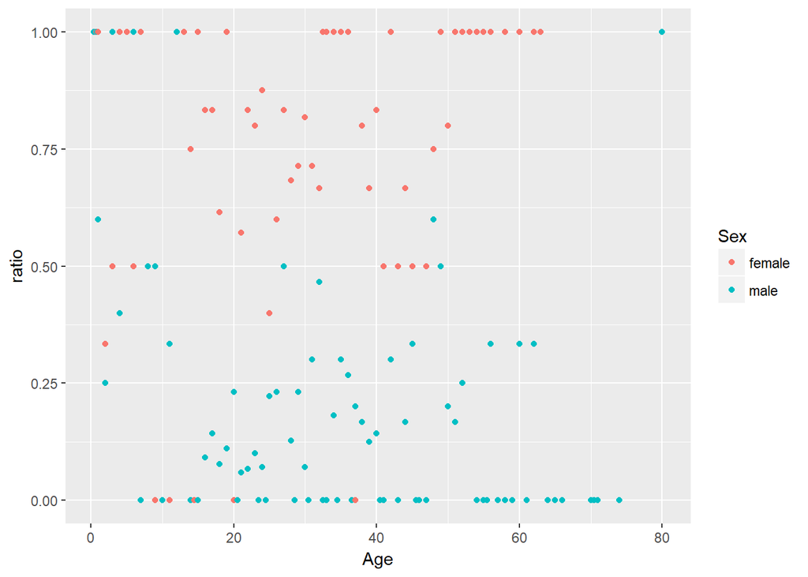

```r
testModel <- function (formula, train,test)
{
  model <- glm(formula=formula, data= train, family="binomial");
  expected <- (test$Survived);
  actual <- (ifelse(predict(model,test,type="response")>.5,1,0));
  confusionMatrix(factor(expected), factor(actual))
  }

factored %>% group_by(Age,Sex) %>% summarize(ratio = mean(Survived)) %>% ggplot(aes(x=Age,y=ratio, color = Sex)) + geom_point()
```

```r
testModel(Survived~Sex*poly(Age,2) + Parch + Pclass + poly(SibSp,3), factored, factored)
```

```
## Confusion Matrix and Statistics
##
##           Reference
## Prediction   0   1
##          0 487  62
##          1  91 251
##
##                Accuracy : 0.8283
##                  95% CI : (0.8019, 0.8525)
##     No Information Rate : 0.6487
##     P-Value [Acc > NIR] : < 2e-16
##
##                   Kappa : 0.6311
##  Mcnemar's Test P-Value : 0.02359
##
##             Sensitivity : 0.8426
##             Specificity : 0.8019
##          Pos Pred Value : 0.8871
##          Neg Pred Value : 0.7339
##              Prevalence : 0.6487
##          Detection Rate : 0.5466
##    Detection Prevalence : 0.6162
##       Balanced Accuracy : 0.8222
##
##        'Positive' Class : 0
##
```